# Bilan de gestion

Foret communale de Couchey (jeu de demonstration) — du 01/01/2016 au 31/12/2025 — Bilan de l’aménagement précédent

**ImportantDonnées de démonstration**

Ce document est engendré à partir d’un **jeu de démonstration**. La commune et la géométrie cadastrale sont réelles, mais **aucune écriture — volume, montant, date, coupe ou visa — ne provient de registres authentiques**. Il illustre la mise en forme, pas la gestion d’une forêt existante.

## 1 Identification

| **Forêt** | Foret communale de Couchey (jeu de demonstration) |
| --- | --- |
| **Régime** | communal |
| **Surface** | 16,37 ha |
| **Période couverte** | Du 2016-01-01 au 2025-12-31 |
| **Référentiel** | amenagement |
| **Édité le** | 24/10/2026 |

### 1.1 Parcellaire

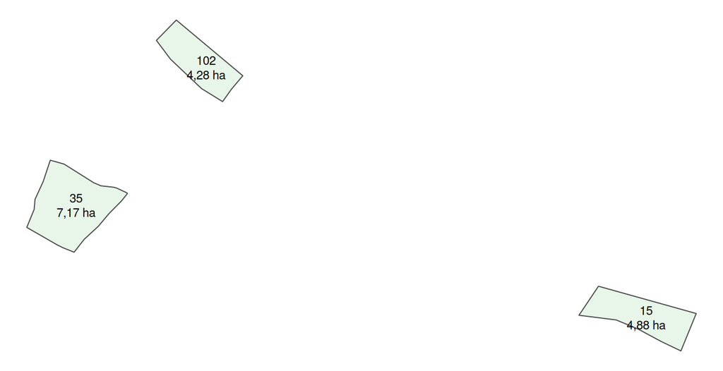

Unités de gestion en vigueur à la fin de la période, avec leur surface.

### 1.2 Récapitulatif du parcellaire

*Fond cadastral non fourni : les ténements ne peuvent pas être calculés. Seules les unités de gestion sont récapitulées.*

Unités de gestion en vigueur

| Unité de gestion | Surface SIG (ha) |
| --- | --- |
| 15 | 4,88 |
| 35 | 7,17 |
| 102 | 4,28 |

### 1.3 Éléments du plan cadastral

*Le plan cadastral (EDIGEO) n’a pas été fourni à ce rendu : les bornes, murs et autres éléments du plan ne sont pas montrés. Le document ne dit pas qu’il n’y en a pas.*

### 1.4 Intégrité du registre

Le sommier est un journal à chaînage de hachages : chaque entrée scelle la précédente. L’état ci-dessous est celui constaté à l’édition de ce document.

| **État de la chaîne** | intacte |
| --- | --- |
| **Entrées** | 76 |
| **Séquence de tête** | 76 |
| **Empreinte de tête** | `1c444497a725c39d3cf74d21fd23f28afa28771a596852208965946b27e635cc` |

## 2 Provenance des écritures

Un sommier ouvert en cours de gestion n’a pas pu constater tout ce que la période contient : ce qui la précède y entre par **transcription**, depuis une pièce citée, avec un niveau de précision (NDP) supérieur à 0. Les deux ne se confondent pas — une recopie n’est pas une mesure, et les tableaux qui suivent portent une colonne `provenance` pour le dire ligne à ligne.

Écritures en vigueur sur la période, par registre et par provenance

| Registre | Constaté | Transcrit | Pièces citées | Transcrit du | au |
| --- | --- | --- | --- | --- | --- |
| 1 — Validations | 4 | 1 | 1 | 2016-01-15 | 2016-01-15 |
| 2 — Foncier & limites | 0 | 1 | 1 | 2017-09-14 | 2017-09-14 |
| 3 — Droits & concessions | 5 | 1 | 1 | 2018-04-01 | 2018-04-01 |
| 4 — Infrastructures | 0 | 3 | 1 | 2016-06-01 | 2016-06-01 |
| 5 — Coupes & récoltes | 6 | 5 | 1 | 2016-03-05 | 2020-03-05 |
| 6 — Travaux | 12 | 0 | 0 | — | — |
| 7 — Comptabilité | 21 | 0 | 0 | — | — |
| 8 — Évènements & faune | 9 | 1 | 1 | 2020-08-10 | 2020-08-10 |
| 9 — Patrimoine remarquable | 4 | 3 | 1 | 2016-07-12 | 2019-06-03 |

**NoteUne partie de ce document est transcrite**

15 écriture(s) sur 76 ont été recopiées de pièces antérieures au sommier, chacune citant la sienne. Elles sont datées du fait, non de leur saisie : la chaîne les a écrites le jour de la transcription, et le dit.

## 3 Coupes et récoltes

Coupes enregistrées sur la période, par exercice et nature, avec les unités parcourues

| Exercice | Unité | Type | Nature | Provenance | Volume (m³) | Surface (ha) | Entrées |
| --- | --- | --- | --- | --- | --- | --- | --- |
| 2016 | 35 | martelage | reguliere | transcrit | 86 | 7,2 | 1 |
| 2017 | 102 | martelage | sanitaire | transcrit | 98 | 4,3 | 1 |
| 2018 | 15 | martelage | amelioration | transcrit | 80 | 4,9 | 1 |
| 2019 | 35 | martelage | reguliere | transcrit | 92 | 7,2 | 1 |
| 2020 | 102 | martelage | sanitaire | transcrit | 74 | 4,3 | 1 |
| 2021 | 15 | martelage | amelioration | constate | 86 | 4,9 | 1 |
| 2022 | 35 | martelage | reguliere | constate | 98 | 7,2 | 1 |
| 2022 | 35 | produit accidentel | chablis | constate | 48 | 1,8 | 1 |
| 2023 | 102 | martelage | sanitaire | constate | 80 | 4,3 | 1 |
| 2024 | 15 | martelage | amelioration | constate | 92 | 4,9 | 1 |
| 2025 | 35 | martelage | reguliere | constate | 74 | 7,2 | 1 |

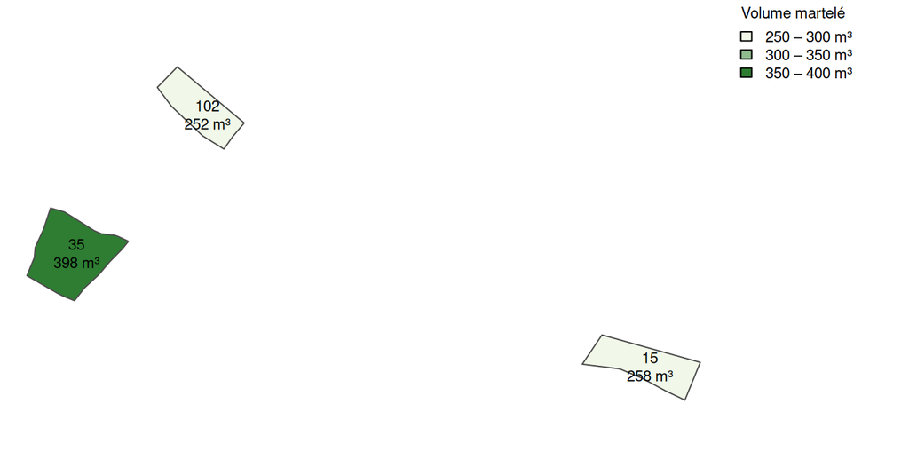

Volume martelé par unité de gestion sur la période.

### 3.1 Balance de possibilité

La balance confronte les volumes **martelés** à la possibilité de l’aménagement. La possibilité se fixe à l’hectare (m³/ha/an) sur une surface ; le volume annuel s’en déduit, et le prélèvement se ramène lui aussi à l’hectare, pour se lire contre la possibilité et contre les références de l’IFN. Une balance positive signale un excès de prélèvement, une balance négative un déficit ; c’est le cumul qui compte, et il repart de zéro avec chaque aménagement.

**Amenagement 2016-2035** (`COUCHEY-2016`), exercices 2016–2035 : 5,00 m³/ha/an sur 16,37 ha, soit 82 m³/an — possibilité fixée par l’acte. Acte : Arrete d’amenagement de la foret communale de Couchey (15/01/2016), transcrit depuis une pièce antérieure.

Balance de possibilité

| Exercice | Possibilité (m³/ha/an) | Possibilité (m³/an) | Martelé (m³) | Prélevé (m³/ha) | Balance (m³) | Balance cumulée (m³) |
| --- | --- | --- | --- | --- | --- | --- |
| 2016 | 5 | 81,9 | 86 | 5,3 | 4,1 | 4,1 |
| 2017 | 5 | 81,9 | 98 | 6,0 | 16,1 | 20,3 |
| 2018 | 5 | 81,9 | 80 | 4,9 | -1,9 | 18,4 |
| 2019 | 5 | 81,9 | 92 | 5,6 | 10,1 | 28,5 |
| 2020 | 5 | 81,9 | 74 | 4,5 | -7,9 | 20,6 |
| 2021 | 5 | 81,9 | 86 | 5,3 | 4,1 | 24,8 |
| 2022 | 5 | 81,9 | 146 | 8,9 | 64,1 | 88,9 |
| 2023 | 5 | 81,9 | 80 | 4,9 | -1,9 | 87,0 |
| 2024 | 5 | 81,9 | 92 | 5,6 | 10,1 | 97,1 |
| 2025 | 5 | 81,9 | 74 | 4,5 | -7,9 | 89,3 |

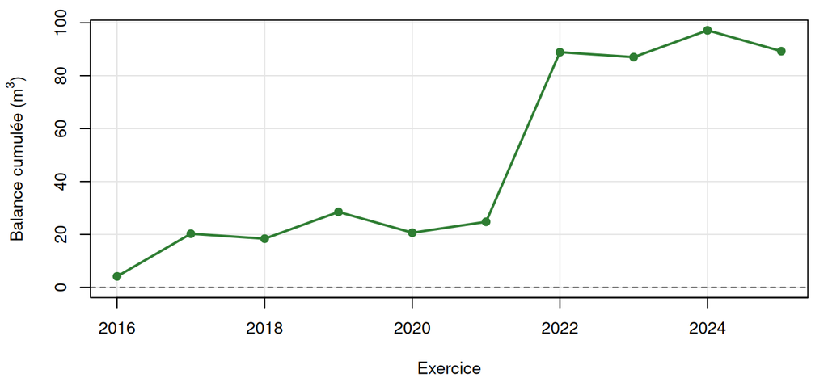

Balance cumulée par aménagement — la ligne pointillée marque l’équilibre, et le cumul repart de zéro à chaque aménagement.

Repères, à l’hectare

| Repère | m³/ha/an |
| --- | --- |
| Possibilité — Amenagement 2016-2035 | 5,00 |
| Prélevé moyen, 2016–2025 (10 exercice(s) échu(s)) | 5,55 |

**Note**

La balance additionne 5 écriture(s) transcrite(s) du registre des coupes avec 6 constatée(s). Le cumul est juste, sa précision est celle de la pièce la moins précise.

## 4 Travaux

La reprise d’une plantation se mesure sur des placettes permanentes, contrôlées à n+1, n+3 et n+5 ; le taux de l’imprimé A50J ne figure que pour les travaux transcrits de l’existant.

Travaux réalisés sur la période, par année et nature, avec les unités concernées

| Année | Unité | Nature | Provenance | Quantité | Unité | Montant (€) | Reprise moyenne (%) | Entrées |
| --- | --- | --- | --- | --- | --- | --- | --- | --- |
| 2022 | 35 | plantation | constate | 1,8 | ha | 5 130 | — | 1 |
| 2023 | — | entretien de la desserte | constate | 1,0 | km | 1 980 | — | 1 |
| 2024 | 35 | degagement | constate | 1,8 | ha | 1 400 | — | 1 |

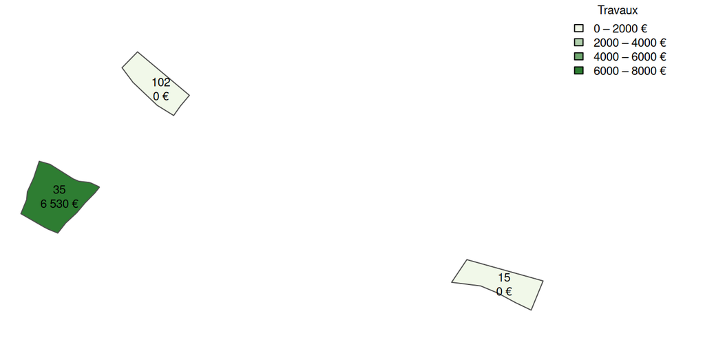

Montant des travaux par unité de gestion. Les travaux hors unité de gestion n’y figurent pas : ils ne se localisent pas.

### 4.1 Suivi des plantations

1 plantation(s) suivie(s) sur 3 placette(s). Chaque point est la moyenne des placettes contrôlées à cet âge ; la ligne pointillée marque le seuil de 80 %, sous lequel une plantation appelle un regarni.

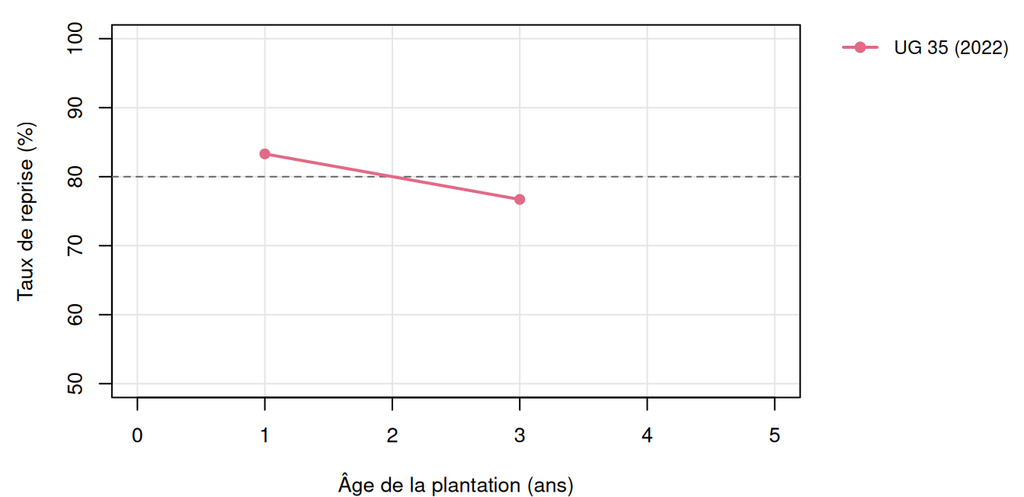

Taux de reprise par âge de plantation, une ligne par plantation suivie.

Mesures des placettes, par plantation et par âge

| Unité | Plantation | Âge (ans) | Placettes | Reprise (%) | Densité (tiges/ha) | Hauteur (cm) | Abroutis (%) | Besoins |
| --- | --- | --- | --- | --- | --- | --- | --- | --- |
| 35 | 2022 | 1 | 3 | 83,3 | 3 332 | 37 | 20,7 | DG |
| 35 | 2022 | 3 | 3 | 76,7 | 3 066 | 89 | 16,3 | DG |

### 4.2 À programmer

Les placettes dont le dernier contrôle signale un besoin. Un état courant : il n’est pas borné par la période du rapport.

Travaux à programmer d’après les placettes

| Unité | Placette | Dernier contrôle | Âge (ans) | Reprise (%) | Abroutis (%) | Concurrence | Besoin |
| --- | --- | --- | --- | --- | --- | --- | --- |
| 35 | P35-03 | 13/06/2025 | 3 | 65,0 | 30,8 | forte | DG — Dégagement (manuel, mécanique) |

### 4.3 Coût à l’hectare

Le montant cumulé des travaux de chaque unité, rapporté à la surface de son contour, par famille de travaux. Les travaux inscrits avant le code des travaux sont rangés « non codés ». Les travaux hors unité de gestion (1 980 €) n’y figurent pas.

[figure not shown]

Coût cumulé des travaux à l’hectare, par unité de gestion et par famille.

### 4.4 Prévu, reporté, non prévu

Les hectares traités chaque année, selon que l’intervention était prévue par le document de gestion, reportée d’un autre exercice, ou non prévue. « Non renseigné » : des travaux inscrits avant que le registre le demande. 1 intervention(s) mesurée(s) autrement qu’en hectares (mètres de clôture, tiges) n’y figurent pas.

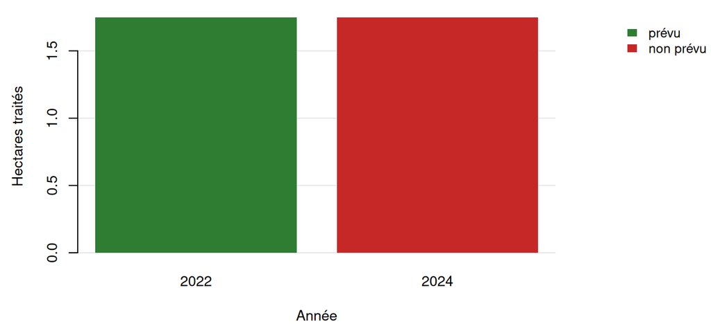

Hectares traités par année, selon l’écart au prévu.

## 5 Évènements marquants

Le niveau de précision (NDP) vaut 0 pour un constat de terrain ; une valeur supérieure signale une observation qui n’en est pas un — issue de la télédétection, ou transcrite d’une pièce antérieure au sommier.

Phénomènes intéressant la vie de la forêt

| Date | Nature | Description | Surface (ha) | Volume impacté (m³) | NDP |
| --- | --- | --- | --- | --- | --- |
| 2020-08-10 | secheresse | Deficit hydrique estival, roussissement des cimes | 6,8 | — | 4 |
| 2022-02-17 | tempete | Coup de vent du 17 fevrier | 1,8 | 48 | 0 |

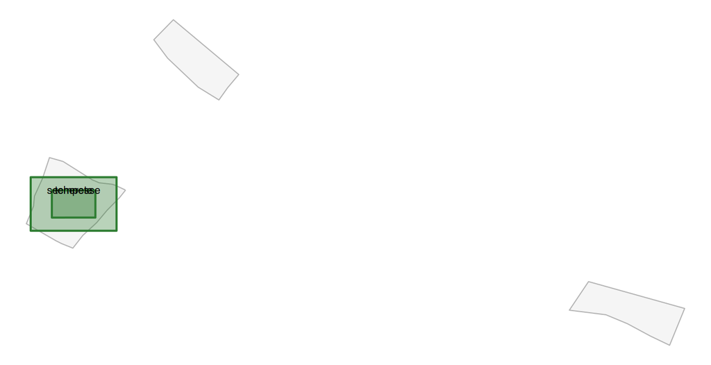

Emprises des phénomènes constatés. Seuls ceux dont le relevé a été porté au registre y figurent.

## 6 Bilan financier

Le solde est la différence entre recettes et dépenses de l’exercice ; le cumul en donne la tendance.

Recettes, dépenses et solde par exercice

| Exercice | Recettes (€) | Dépenses (€) | Solde (€) | Solde cumulé (€) |
| --- | --- | --- | --- | --- |
| 2021 | 5 990 | 520 | 5 470 | 5 470 |
| 2022 | 6 340 | 5 650 | 690 | 6 160 |
| 2023 | 6 690 | 520 | 6 170 | 12 330 |
| 2024 | 7 040 | 520 | 6 520 | 18 850 |
| 2025 | 7 390 | 520 | 6 870 | 25 720 |

## 7 Équilibre forêt-gibier

Obligatoire dans les plans simples de gestion depuis la loi d’avenir pour l’agriculture, l’alimentation et la forêt du 13 octobre 2014.

Constats d’équilibre forêt-gibier

| Saison | Surface sensible (ha) | Abroutissement (%) | Diagnostic |
| --- | --- | --- | --- |
| 2021-2022 | 3,1 | 31 | desequilibre leger |
| 2022-2023 | 3,1 | 29 | desequilibre leger |
| 2023-2024 | 3,1 | 27 | desequilibre leger |
| 2024-2025 | 3,1 | 25 | desequilibre leger |

## 8 Patrimoine remarquable

Dernier relevé connu de chaque sujet : le patrimoine est un état courant, il n’est pas borné par la période du rapport.

Arbres, peuplements, vestiges, espèces et habitats

| Fiche | Appellation | Nom latin | Habitat | Surface (ha) | État sanitaire | Protection | CD_NOM |
| --- | --- | --- | --- | --- | --- | --- | --- |
| arbre | Alisier de la lisiere sud | — | — | — | bon | — | — |
| arbre | Chandelle du talus est | — | — | — | mort | — | — |
| arbre | Chene de la Justice | — | — | — | moyen | — | — |
| espece | Sabot de Venus | Cypripedium calceolus | — | — | — | Directive Habitats, annexe II | — |
| habitat | — | — | Pelouse calcicole seche | 1,3 | — | — | — |
| vestige | Charbonniere de la section A | — | — | — | — | — | — |

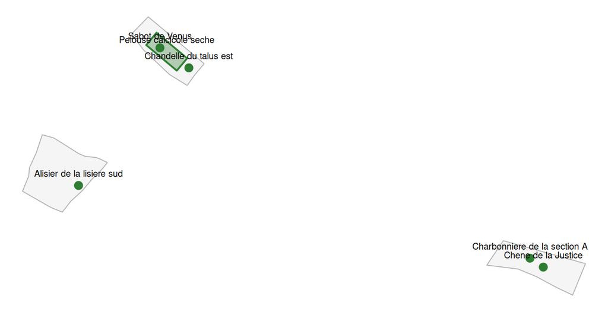

Patrimoine remarquable localisé : arbres, vestiges, espèces, habitats.

### 8.1 Éléments utiles à l’IBP

Ce que le registre 9 apporte à l’Indice de Biodiversité Potentielle. **Ce n’est pas une cotation** : un facteur IBP se cote sur placette selon son protocole de terrain, pas par comptage d’un registre qui n’inventorie que le remarquable.

Éléments mobilisables pour l’IBP

| Facteur IBP | Élément | Valeur | Unité | Entrées |
| --- | --- | --- | --- | --- |
| F - arbres a microhabitats | Arbres remarquables vivants au registre 9 | 2,0 | arbres | 3 |
| C - bois mort sur pied | Arbres remarquables releves morts sur pied | 1,0 | arbres | 3 |
| E - tres gros bois vivants | Arbres vivants de circonference >= 220 cm | 1,0 | arbres | 3 |
| G - milieux ouverts | Habitats remarquables au libelle evoquant un milieu ouvert | 1,3 | ha | 1 |
| contexte - especes protegees | Especes protegees inventoriees | 1,0 | especes | 1 |

## 9 Desserte

Seule la voirie privée forestière entre dans la densité : une route publique traversant la forêt ne dit rien de sa desserte.

Longueurs et densités de voirie

| revetement | longueur_km | densite_km_100ha |
| --- | --- | --- |
| empierree | 1.04 | 6.35 |
| terrain_naturel | 0.48 | 2.93 |
| total | 1.52 | 9.28 |

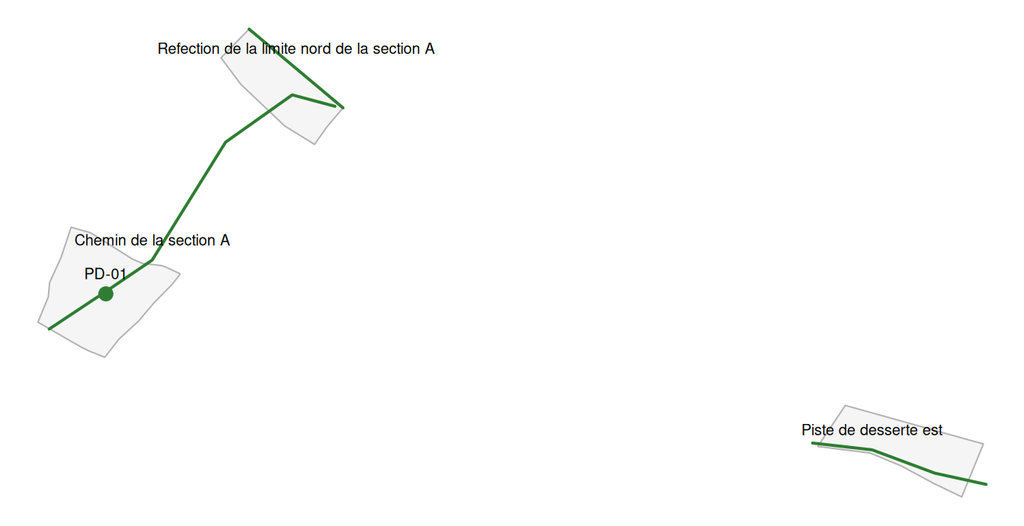

Voirie et équipements portés au registre 4, et limites relevées au registre 2.

## 10 Vérifier ce document

Ce rapport est une **mise en forme**, pas la preuve. La valeur probante tient au registre lui-même : l’empreinte de tête donnée plus haut scelle les 76 entrées de la chaîne.

Pour contrôler ces chiffres sans accès à la base, demander l’export manifeste et le vérifier hors ligne :

```r
sommier_verifier_manifeste("sommier-export.json")
```

Toute entrée modifiée, retirée ou insérée après coup invalide l’empreinte de tête, et la vérification le dit.

Le détail de chaque écriture, rectifiées comprises, est dans le sommier imprimé (`sommier_registre_quarto()`).

*Engendré par sommieR 0.37.1 le 24/10/2026.*